# Simple_timeseries_NN

## Neural Network

```python
%matplotlib inline
%config InlineBackend.figure_format = 'retina'

import numpy as np
import pandas as pd
import matplotlib.pyplot as plt
```

## Load and prepare the data

Variables on different scales make it difficult for the network to efficiently learn the correct weights.

```python
data_path = 'Dataset/tub_71_18-02-04.csv' #For this test IMU stops at arround 8000
boat_log = pd.read_csv(data_path)
```

```python
boat_log.head()
```

|  | acc_x | acc_y | acc_z | gyro_x | gyro_y | gyro_z | mag_x | mag_y | mag_z | position_timestamp | position_x | position_y | time_stamp | user_angle | user_mode | user_throttle |
| --- | --- | --- | --- | --- | --- | --- | --- | --- | --- | --- | --- | --- | --- | --- | --- | --- |
| 0 | -0.135 | 0.036 | 1.039 | -4.883 | 1.030 | 0.938 | -22.404 | 28.952 | -17.138 | -1.0 | -1.0 | -1.0 | 1517772242 | -1.387779e-16 | user | 2.775558e-17 |
| 1 | -0.134 | 0.033 | 1.038 | -5.432 | 0.816 | 0.877 | -21.891 | 28.779 | -17.318 | -1.0 | -1.0 | -1.0 | 1517772242 | -1.387779e-16 | user | 2.775558e-17 |
| 2 | -0.132 | 0.029 | 1.037 | -5.165 | 0.809 | 0.908 | -21.891 | 28.779 | -17.318 | -1.0 | -1.0 | -1.0 | 1517772242 | -1.387779e-16 | user | 2.775558e-17 |
| 3 | -0.132 | 0.031 | 1.040 | -4.227 | 0.809 | 0.862 | -23.088 | 28.259 | -17.498 | -1.0 | -1.0 | -1.0 | 1517772242 | -1.387779e-16 | user | 2.775558e-17 |
| 4 | -0.131 | 0.028 | 1.042 | -3.326 | 0.885 | 0.854 | -23.088 | 28.259 | -17.498 | -1.0 | -1.0 | -1.0 | 1517772242 | -1.387779e-16 | user | 2.775558e-17 |

## Checking out the data

Below is a plot showing the position and orientation of the boat in a range from a to b. (Some position don't have exactl entries in the data set.) Looking at the data above, we also have information about orientation, acceleration, user throttle, and user angle. All of these likely affecting the postion and orientation. All this will be capture with this model.

```
6113
```

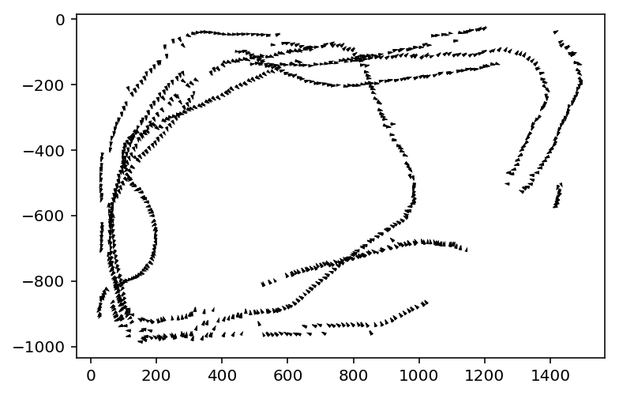

```python
#Remove all entries without position data and irelevent data
filtered = boat_log[1400:8683]
filtered = filtered.query('position_x>0');
print(len(filtered))
#Quiver Plot for postion and orientation
a = 3000; b = 7000 #One loop sample
U = np.ones_like(len(filtered.position_x[a:b]))
V = np.ones_like(len(filtered.position_y[a:b]))

#Map range to degrees in confirmed circles
#mag_y_local = filtered.mag_y[a:b]
#correction = (filtered.mag_y - (mag_y_local.min() + mag_y_local.max())/2) #center

mag_degrees = np.interp(filtered.mag_y, [9, 34.5], [0, 360]) ##9 and 34.5 are averaged local min and max form iterations of 1000
#Add boat orientation compensation
mag_bc = mag_degrees+60
phi = mag_bc[a:b]
# Render Plot
fig, ax = plt.subplots();
ax.quiver(filtered.position_x[a:b], -filtered.position_y[a:b], U, V, angles=phi)
plt.savefig('/home/sander/Desktop/fig1.svg')
plt.figure();
```

```python
fields_to_drop = ['user_mode']

data = filtered.drop(fields_to_drop, axis=1)
#data = filtered.drop(fields_to_drop, axis=1)
data.head()
```

|  | acc_x | acc_y | acc_z | gyro_x | gyro_y | gyro_z | mag_x | mag_y | mag_z | position_timestamp | position_x | position_y | time_stamp | user_angle | user_throttle |
| --- | --- | --- | --- | --- | --- | --- | --- | --- | --- | --- | --- | --- | --- | --- | --- |
| 1404 | -0.117 | -0.004 | 1.173 | -0.282 | 0.786 | -5.775 | -4.276 | 12.656 | -12.808 | 1.517773e+09 | 1145.340625 | 536.574074 | 1517772326 | 0.1 | 0.8 |
| 1405 | -0.087 | 0.117 | 1.046 | -0.061 | 0.443 | -5.272 | -4.276 | 12.656 | -12.808 | 1.517773e+09 | 1145.340625 | 536.574074 | 1517772326 | 0.1 | 0.8 |
| 1406 | -0.244 | -0.017 | 1.000 | -1.373 | 0.549 | -4.753 | -3.592 | 12.656 | -11.726 | 1.517773e+09 | 1145.340625 | 536.574074 | 1517772326 | 0.1 | 0.8 |
| 1407 | -0.136 | -0.058 | 1.201 | -2.327 | -0.130 | -4.295 | -3.592 | 12.656 | -11.726 | 1.517773e+09 | 1145.340625 | 536.574074 | 1517772326 | 0.1 | 0.8 |
| 1408 | -0.210 | 0.135 | 0.856 | -2.937 | 0.610 | -4.059 | -3.592 | 12.656 | -11.726 | 1.517773e+09 | 1127.018750 | 548.611111 | 1517772327 | 0.1 | 0.8 |

## Scaling target variables

To make training the network easier, each of the continuous variables are standardize. That is, the scale variables are shifted such that they have zero mean and a standard deviation of 1. The scaling factors are saved in order to go backwards and use the network for predictions.

```python
quant_features = ['acc_x', 'acc_y', 'acc_z', 'gyro_x', 'gyro_y', 'gyro_z', 'mag_x', 'mag_y', 'mag_z', 'position_timestamp', 'position_x', 'position_y', 'time_stamp', 'user_angle', 'user_throttle']
# Store scalings in a dictionary so we can convert back later
scaled_features = {}
for each in quant_features:
    mean, std = data[each].mean(), data[each].std()
    scaled_features[each] = [mean, std]
    data.loc[:, each] = (data[each] - mean)/std
```

### Splitting the data into training, testing, and validation sets

```python
# Save test data
test_data = data[2000:]

# Now remove the test data from the data set
data = data[:-2000]

# Separate the data into features and targets
target_fields = ['mag_y', 'position_x', 'position_y']
features, targets = data.drop(target_fields, axis=1), data[target_fields]
test_features, test_targets = test_data.drop(target_fields, axis=1), test_data[target_fields]

features.head()
```

|  | acc_x | acc_y | acc_z | gyro_x | gyro_y | gyro_z | mag_x | mag_z | position_timestamp | time_stamp | user_angle | user_throttle |
| --- | --- | --- | --- | --- | --- | --- | --- | --- | --- | --- | --- | --- |
| 1404 | 0.828049 | -0.341058 | 0.813361 | 0.353765 | 0.204535 | -0.038151 | 1.311686 | 1.032190 | -1.493146 | -1.495557 | -0.334842 | 0.29072 |
| 1405 | 1.296637 | 0.667047 | 0.071165 | 0.417505 | -0.089868 | 0.008399 | 1.311686 | 1.032190 | -1.493146 | -1.495557 | -0.334842 | 0.29072 |
| 1406 | -1.155642 | -0.449366 | -0.197662 | 0.039105 | 0.001114 | 0.056430 | 1.422329 | 1.493342 | -1.493146 | -1.495557 | -0.334842 | 0.29072 |
| 1407 | 0.531276 | -0.790955 | 0.976995 | -0.236042 | -0.581683 | 0.098815 | 1.422329 | 1.493342 | -1.493146 | -1.495557 | -0.334842 | 0.29072 |
| 1408 | -0.624575 | 0.817013 | -1.039207 | -0.411975 | 0.053472 | 0.120656 | 1.422329 | 1.493342 | -1.491913 | -1.488905 | -0.334842 | 0.29072 |

We'll split the data into two sets, one for training and one for validating as the network is being trained. Since this is time series data, we'll train on historical data, then try to predict on future data (the validation set).

```python
# Hold out the last iterations of the remaining data as a validation set
train_features, train_targets = features[:-3000], targets[:-3000]
val_features, val_targets = features[-3000:], targets[-3000:]
```

```python
class NeuralNetwork(object):
    def __init__(self, input_nodes, hidden_nodes, output_nodes, learning_rate):
        # Set number of nodes in input, hidden and output layers.
        self.input_nodes = input_nodes
        self.hidden_nodes = hidden_nodes
        self.output_nodes = output_nodes

        # Initialize weights
        self.weights_input_to_hidden = np.random.normal(0.0, self.input_nodes**-0.5,
                                       (self.input_nodes, self.hidden_nodes))

        self.weights_hidden_to_output = np.random.normal(0.0, self.hidden_nodes**-0.5,
                                       (self.hidden_nodes, self.output_nodes))
        self.lr = learning_rate

        self.activation_function = lambda x : 1/(1+np.exp(-x))  # Replace 0 with your sigmoid calculation.

    def train(self, features, targets):

        n_records = features.shape[0]
        delta_weights_i_h = np.zeros(self.weights_input_to_hidden.shape)
        delta_weights_h_o = np.zeros(self.weights_hidden_to_output.shape)
        for X, y in zip(features, targets):

            ### Forward pass ###
            hidden_inputs = np.dot(X, self.weights_input_to_hidden) # WX multiply the weights the data signals into hidden layer
            hidden_outputs = self.activation_function(hidden_inputs) # f(h) signals from hidden layer
            final_inputs = np.dot(hidden_outputs, self.weights_hidden_to_output) # signals into final output layer
            final_outputs = final_inputs #G f(x) = x signals from final output layer

            ### Backward pass ###
            error = y - final_outputs # y-ŷ Output layer error is the difference between desired target and actual output.

            # Calculate the hidden layer's contribution to the error
            hidden_error = np.dot(self.weights_hidden_to_output, error) # 𝛿^o  #R

            # Backpropagated error terms
            output_error_term = error
            hidden_error_term = hidden_error * hidden_outputs * (1 - hidden_outputs) # w 𝛿^o f'(h)

            delta_weights_i_h += hidden_error_term * X[:, None] # Weight step (input to hidden)
            delta_weights_h_o += output_error_term * hidden_outputs[:, None] #ΔW_o = w 𝛿^o #R

        self.weights_hidden_to_output += self.lr * delta_weights_h_o / n_records # update hidden-to-output weights with gradient descent step
        self.weights_input_to_hidden += self.lr * delta_weights_i_h / n_records # η ΔW/m update input-to-hidden weights with gradient descent step


    def run(self, features):
        #### Forward pass here ####
        hidden_inputs = np.dot(features, self.weights_input_to_hidden) # 2 signals into hidden layer
        hidden_outputs = self.activation_function(hidden_inputs)# 2 signals from hidden layer
        final_inputs = np.dot(hidden_outputs, self.weights_hidden_to_output)# signals into final output layer
        final_outputs = final_inputs # signals from final output layer

        return final_outputs
```

```python
def MSE(y, Y):
    return np.mean((y-Y)**2)
```

```python
import sys

### Set the hyperparameters here ###
iterations = 5000    #100
learning_rate = 0.001    #0.1 self.lr / n_records
hidden_nodes = 17    #2 original #5 worls well
output_nodes = 1    #1 original #3 works well

N_i = train_features.shape[1]
network = NeuralNetwork(N_i, hidden_nodes, output_nodes, learning_rate)

losses = {'train':[], 'validation':[]}
for ii in range(iterations):
    # Go through a random batch of 128 records from the training data set
    batch = np.random.choice(train_features.index, size=128)
    X, y = train_features.ix[batch].values, train_targets.ix[batch]['mag_y']#['cnt']

    network.train(X, y)

    # Printing out the training progress
    #train_loss = MSE(network.run(train_features).T, train_targets['cnt'].values)
    train_loss = MSE(network.run(train_features).T, train_targets['mag_y'].values)
    val_loss = MSE(network.run(val_features).T, val_targets['mag_y'].values)
    sys.stdout.write("\rProgress: {:2.1f}".format(100 * ii/float(iterations)) \
                     + "% ... Training loss: " + str(train_loss)[:5] \
                     + " ... Validation loss: " + str(val_loss)[:5])
    sys.stdout.flush()

    losses['train'].append(train_loss)
    losses['validation'].append(val_loss)
```

```
Progress: 0.2% ... Training loss: 1.340 ... Validation loss: 1.369
```

```
Progress: 100.0% ... Training loss: 0.554 ... Validation loss: 0.943
```

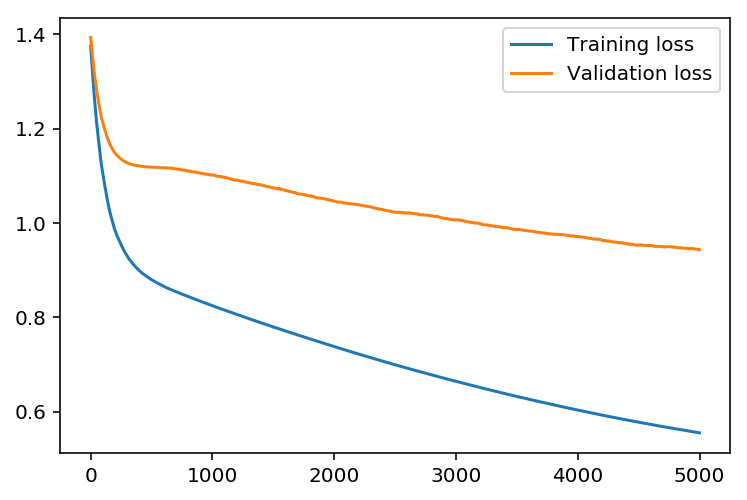

```python
plt.plot(losses['train'], label='Training loss')
plt.plot(losses['validation'], label='Validation loss')
plt.legend()
_ = plt.ylim()
```

## Predictions

Network Performance. If something is completely wrong here, make sure each step in your network is implemented correctly.

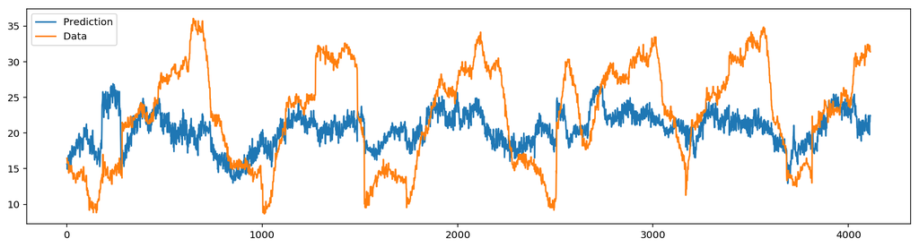

```python
fig, ax = plt.subplots(figsize=(16,4))

mean, std = scaled_features['mag_y']
predictions = network.run(test_features).T*std + mean
predition2 = predictions[0]
test = (test_targets['mag_y']*std + mean).values
plt.plot(predition2, label='Prediction');
plt.plot((test_targets['mag_y']*std + mean).values, label='Data')
plt.legend()
```